# Lab 2

# 9.(a)

> quan: mpg, acceleration, weight, horsepower, displacement qual: origin, year, cylinders

# 9.(b,C)

```r
summary(Auto)
```

```
##       mpg          cylinders      displacement     horsepower
##  Min.   : 9.00   Min.   :3.000   Min.   : 68.0   Min.   : 46.0
##  1st Qu.:17.00   1st Qu.:4.000   1st Qu.:105.0   1st Qu.: 75.0
##  Median :22.75   Median :4.000   Median :151.0   Median : 93.5
##  Mean   :23.45   Mean   :5.472   Mean   :194.4   Mean   :104.5
##  3rd Qu.:29.00   3rd Qu.:8.000   3rd Qu.:275.8   3rd Qu.:126.0
##  Max.   :46.60   Max.   :8.000   Max.   :455.0   Max.   :230.0
##
##      weight      acceleration        year           origin
##  Min.   :1613   Min.   : 8.00   Min.   :70.00   Min.   :1.000
##  1st Qu.:2225   1st Qu.:13.78   1st Qu.:73.00   1st Qu.:1.000
##  Median :2804   Median :15.50   Median :76.00   Median :1.000
##  Mean   :2978   Mean   :15.54   Mean   :75.98   Mean   :1.577
##  3rd Qu.:3615   3rd Qu.:17.02   3rd Qu.:79.00   3rd Qu.:2.000
##  Max.   :5140   Max.   :24.80   Max.   :82.00   Max.   :3.000
##
##                  name
##  amc matador       :  5
##  ford pinto        :  5
##  toyota corolla    :  5
##  amc gremlin       :  4
##  amc hornet        :  4
##  chevrolet chevette:  4
##  (Other)           :365
```

```r
str(Auto)
```

```
## 'data.frame':    392 obs. of  9 variables:
##  $ mpg         : num  18 15 18 16 17 15 14 14 14 15 ...
##  $ cylinders   : int  8 8 8 8 8 8 8 8 8 8 ...
##  $ displacement: num  307 350 318 304 302 429 454 440 455 390 ...
##  $ horsepower  : int  130 165 150 150 140 198 220 215 225 190 ...
##  $ weight      : int  3504 3693 3436 3433 3449 4341 4354 4312 4425 3850 ...
##  $ acceleration: num  12 11.5 11 12 10.5 10 9 8.5 10 8.5 ...
##  $ year        : int  70 70 70 70 70 70 70 70 70 70 ...
##  $ origin      : int  1 1 1 1 1 1 1 1 1 1 ...
##  $ name        : Factor w/ 304 levels "amc ambassador brougham",..: 49 36 231 14 161 141 54 223 241 2 ...
##  - attr(*, "na.action")=Class 'omit'  Named int [1:5] 33 127 331 337 355
##   .. ..- attr(*, "names")= chr [1:5] "33" "127" "331" "337" ...
```

```r
summary(mpg)
```

```
##    Min. 1st Qu.  Median    Mean 3rd Qu.    Max.
##    9.00   17.00   22.75   23.45   29.00   46.60
```

```r
range(mpg)
```

```
## [1]  9.0 46.6
```

```r
range(acceleration)
```

```
## [1]  8.0 24.8
```

```r
range(displacement)
```

```
## [1]  68 455
```

```r
range(horsepower)
```

```
## [1]  46 230
```

```r
range(weight)
```

```
## [1] 1613 5140
```

```r
sd(mpg)
```

```
## [1] 7.805007
```

```r
sd(acceleration)
```

```
## [1] 2.758864
```

```r
sd(displacement)
```

```
## [1] 104.644
```

```r
sd(horsepower)
```

```
## [1] 38.49116
```

```r
sd(weight)
```

```
## [1] 849.4026
```

# 9.(d)

```r
new.Auto = Auto[-c(10:85),]
#new.Auto
#Auto

summary(Auto)
```

```
##       mpg          cylinders      displacement     horsepower
##  Min.   : 9.00   Min.   :3.000   Min.   : 68.0   Min.   : 46.0
##  1st Qu.:17.00   1st Qu.:4.000   1st Qu.:105.0   1st Qu.: 75.0
##  Median :22.75   Median :4.000   Median :151.0   Median : 93.5
##  Mean   :23.45   Mean   :5.472   Mean   :194.4   Mean   :104.5
##  3rd Qu.:29.00   3rd Qu.:8.000   3rd Qu.:275.8   3rd Qu.:126.0
##  Max.   :46.60   Max.   :8.000   Max.   :455.0   Max.   :230.0
##
##      weight      acceleration        year           origin
##  Min.   :1613   Min.   : 8.00   Min.   :70.00   Min.   :1.000
##  1st Qu.:2225   1st Qu.:13.78   1st Qu.:73.00   1st Qu.:1.000
##  Median :2804   Median :15.50   Median :76.00   Median :1.000
##  Mean   :2978   Mean   :15.54   Mean   :75.98   Mean   :1.577
##  3rd Qu.:3615   3rd Qu.:17.02   3rd Qu.:79.00   3rd Qu.:2.000
##  Max.   :5140   Max.   :24.80   Max.   :82.00   Max.   :3.000
##
##                  name
##  amc matador       :  5
##  ford pinto        :  5
##  toyota corolla    :  5
##  amc gremlin       :  4
##  amc hornet        :  4
##  chevrolet chevette:  4
##  (Other)           :365
```

```r
summary(new.Auto)
```

```
##       mpg          cylinders      displacement     horsepower
##  Min.   :11.00   Min.   :3.000   Min.   : 68.0   Min.   : 46.0
##  1st Qu.:18.00   1st Qu.:4.000   1st Qu.:100.2   1st Qu.: 75.0
##  Median :23.95   Median :4.000   Median :145.5   Median : 90.0
##  Mean   :24.40   Mean   :5.373   Mean   :187.2   Mean   :100.7
##  3rd Qu.:30.55   3rd Qu.:6.000   3rd Qu.:250.0   3rd Qu.:115.0
##  Max.   :46.60   Max.   :8.000   Max.   :455.0   Max.   :230.0
##
##      weight      acceleration        year           origin
##  Min.   :1649   Min.   : 8.50   Min.   :70.00   Min.   :1.000
##  1st Qu.:2214   1st Qu.:14.00   1st Qu.:75.00   1st Qu.:1.000
##  Median :2792   Median :15.50   Median :77.00   Median :1.000
##  Mean   :2936   Mean   :15.73   Mean   :77.15   Mean   :1.601
##  3rd Qu.:3508   3rd Qu.:17.30   3rd Qu.:80.00   3rd Qu.:2.000
##  Max.   :4997   Max.   :24.80   Max.   :82.00   Max.   :3.000
##
##                         name
##  ford pinto               :  5
##  toyota corolla           :  5
##  amc matador              :  4
##  chevrolet chevette       :  4
##  amc hornet               :  3
##  chevrolet caprice classic:  3
##  (Other)                  :292
```

```r
range(new.Auto$mpg)
```

```
## [1] 11.0 46.6
```

```r
range(new.Auto$acceleration)
```

```
## [1]  8.5 24.8
```

```r
range(new.Auto$displacement)
```

```
## [1]  68 455
```

```r
range(new.Auto$horsepower)
```

```
## [1]  46 230
```

```r
range(new.Auto$weight)
```

```
## [1] 1649 4997
```

```r
sd(new.Auto$mpg)
```

```
## [1] 7.867283
```

```r
sd(new.Auto$acceleration)
```

```
## [1] 2.693721
```

```r
sd(new.Auto$displacement)
```

```
## [1] 99.67837
```

```r
sd(new.Auto$horsepower)
```

```
## [1] 35.70885
```

```r
sd(new.Auto$weight)
```

```
## [1] 811.3002
```

# 9.(e)

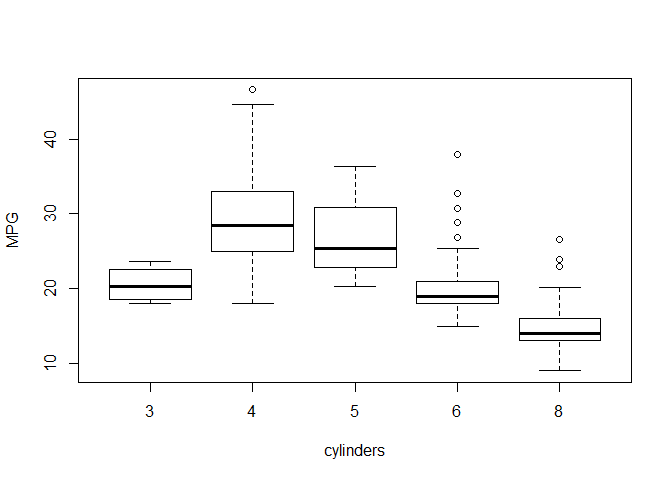

```r
#9.(e)
plot(cylinders, mpg, xlab="cylinders", ylab="MPG")
```

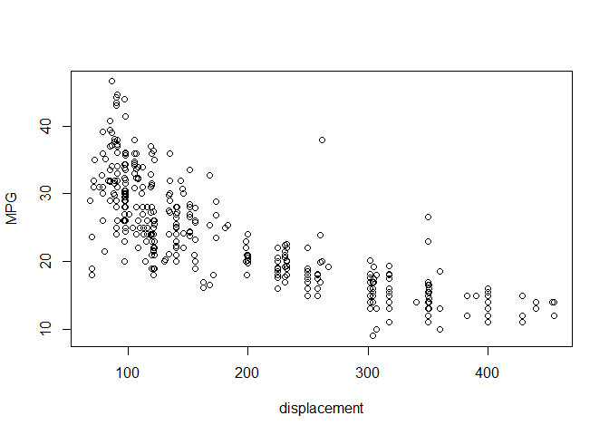

```r
plot(displacement, mpg, xlab="displacement", ylab="MPG")
```

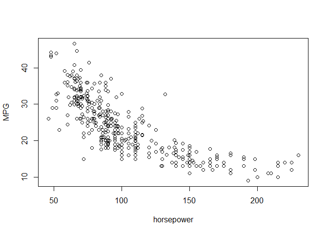

```r
plot(horsepower, mpg, xlab="horsepower", ylab="MPG")
```

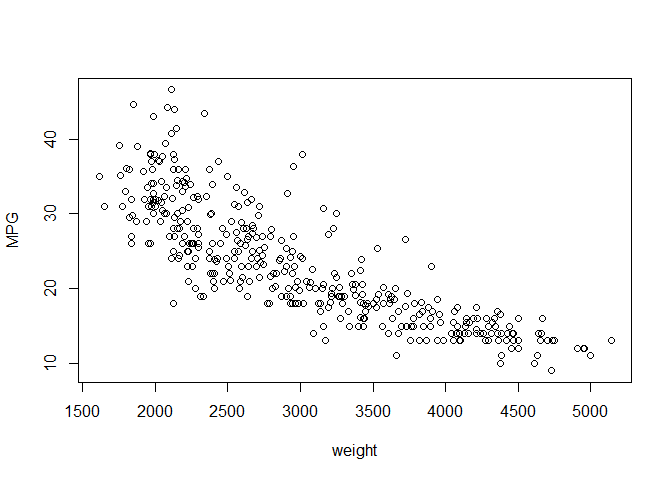

```r
plot(weight, mpg, xlab="weight", ylab="MPG")
```

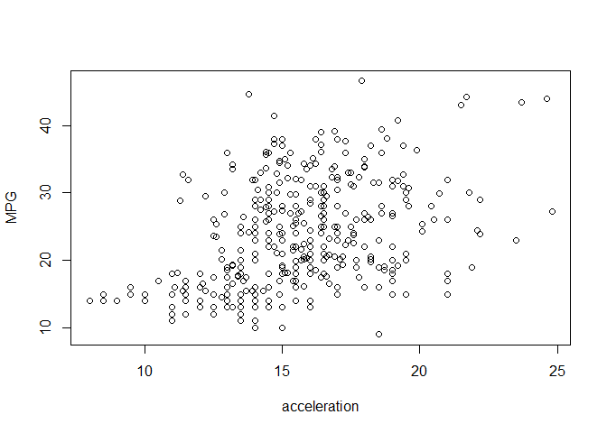

```r
plot(acceleration, mpg, xlab="acceleration", ylab="MPG")
```

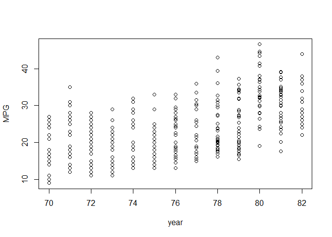

```r
plot(year, mpg, xlab="year", ylab="MPG")
```

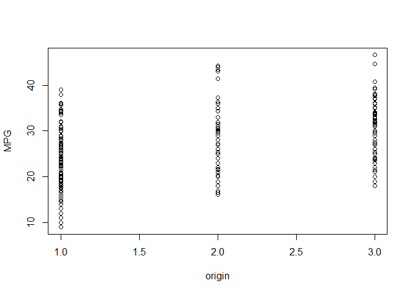

```r
plot(origin, mpg, xlab="origin", ylab="MPG")
```

# 9.(f) > The cars with lower displacement, horsepower, weight have higher gas mileage (mpg).

# 10.(a)

```r
#10.
#(a)
library (MASS)
#Boston
#?Boston
summary(Boston)
```

```
##       crim                zn             indus            chas
##  Min.   : 0.00632   Min.   :  0.00   Min.   : 0.46   Min.   :0.00000
##  1st Qu.: 0.08204   1st Qu.:  0.00   1st Qu.: 5.19   1st Qu.:0.00000
##  Median : 0.25651   Median :  0.00   Median : 9.69   Median :0.00000
##  Mean   : 3.61352   Mean   : 11.36   Mean   :11.14   Mean   :0.06917
##  3rd Qu.: 3.67708   3rd Qu.: 12.50   3rd Qu.:18.10   3rd Qu.:0.00000
##  Max.   :88.97620   Max.   :100.00   Max.   :27.74   Max.   :1.00000
##       nox               rm             age              dis
##  Min.   :0.3850   Min.   :3.561   Min.   :  2.90   Min.   : 1.130
##  1st Qu.:0.4490   1st Qu.:5.886   1st Qu.: 45.02   1st Qu.: 2.100
##  Median :0.5380   Median :6.208   Median : 77.50   Median : 3.207
##  Mean   :0.5547   Mean   :6.285   Mean   : 68.57   Mean   : 3.795
##  3rd Qu.:0.6240   3rd Qu.:6.623   3rd Qu.: 94.08   3rd Qu.: 5.188
##  Max.   :0.8710   Max.   :8.780   Max.   :100.00   Max.   :12.127
##       rad              tax           ptratio          black
##  Min.   : 1.000   Min.   :187.0   Min.   :12.60   Min.   :  0.32
##  1st Qu.: 4.000   1st Qu.:279.0   1st Qu.:17.40   1st Qu.:375.38
##  Median : 5.000   Median :330.0   Median :19.05   Median :391.44
##  Mean   : 9.549   Mean   :408.2   Mean   :18.46   Mean   :356.67
##  3rd Qu.:24.000   3rd Qu.:666.0   3rd Qu.:20.20   3rd Qu.:396.23
##  Max.   :24.000   Max.   :711.0   Max.   :22.00   Max.   :396.90
##      lstat            medv
##  Min.   : 1.73   Min.   : 5.00
##  1st Qu.: 6.95   1st Qu.:17.02
##  Median :11.36   Median :21.20
##  Mean   :12.65   Mean   :22.53
##  3rd Qu.:16.95   3rd Qu.:25.00
##  Max.   :37.97   Max.   :50.00
```

```r
str(Boston)
```

```
## 'data.frame':    506 obs. of  14 variables:
##  $ crim   : num  0.00632 0.02731 0.02729 0.03237 0.06905 ...
##  $ zn     : num  18 0 0 0 0 0 12.5 12.5 12.5 12.5 ...
##  $ indus  : num  2.31 7.07 7.07 2.18 2.18 2.18 7.87 7.87 7.87 7.87 ...
##  $ chas   : int  0 0 0 0 0 0 0 0 0 0 ...
##  $ nox    : num  0.538 0.469 0.469 0.458 0.458 0.458 0.524 0.524 0.524 0.524 ...
##  $ rm     : num  6.58 6.42 7.18 7 7.15 ...
##  $ age    : num  65.2 78.9 61.1 45.8 54.2 58.7 66.6 96.1 100 85.9 ...
##  $ dis    : num  4.09 4.97 4.97 6.06 6.06 ...
##  $ rad    : int  1 2 2 3 3 3 5 5 5 5 ...
##  $ tax    : num  296 242 242 222 222 222 311 311 311 311 ...
##  $ ptratio: num  15.3 17.8 17.8 18.7 18.7 18.7 15.2 15.2 15.2 15.2 ...
##  $ black  : num  397 397 393 395 397 ...
##  $ lstat  : num  4.98 9.14 4.03 2.94 5.33 ...
##  $ medv   : num  24 21.6 34.7 33.4 36.2 28.7 22.9 27.1 16.5 18.9 ...
```

```r
dim(Boston)
```

```
## [1] 506  14
```

> 506 rows and 14 columns

> This data frame contains the following columns:

crim per capita crime rate by town.

zn proportion of residential land zoned for lots over 25,000 sq.ft.

indus proportion of non-retail business acres per town.

chas Charles River dummy variable (= 1 if tract bounds river; 0 otherwise).

nox nitrogen oxides concentration (parts per 10 million).

rm average number of rooms per dwelling.

age proportion of owner-occupied units built prior to 1940.

dis weighted mean of distances to five Boston employment centres.

rad index of accessibility to radial highways.

tax full-value property-tax rate per $10,000.

ptratio pupil-teacher ratio by town.

black 1000(Bk - 0.63)^2 where Bk is the proportion of blacks by town.

lstat lower status of the population (percent).

medv median value of owner-occupied homes in $1000s.

# 10(b-c)

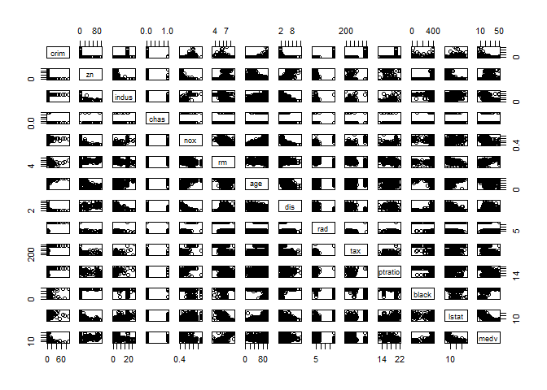

```r
#(b)
pairs(Boston)
```

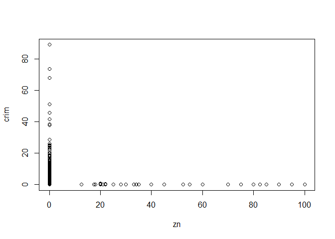

```r
#(c)
attach(Boston)
plot(zn, crim, xlab="zn", ylab="crim")
```

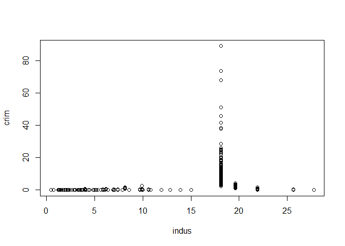

```r
plot(indus, crim, xlab="indus", ylab="crim")
```

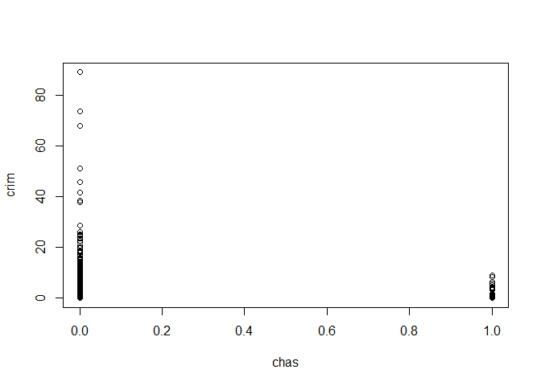

```r
plot(chas, crim, xlab="chas", ylab="crim")
```

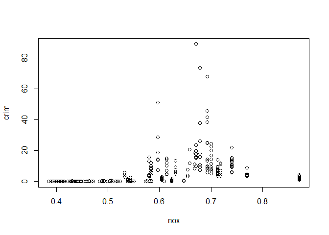

```r
plot(nox, crim, xlab="nox", ylab="crim")
```

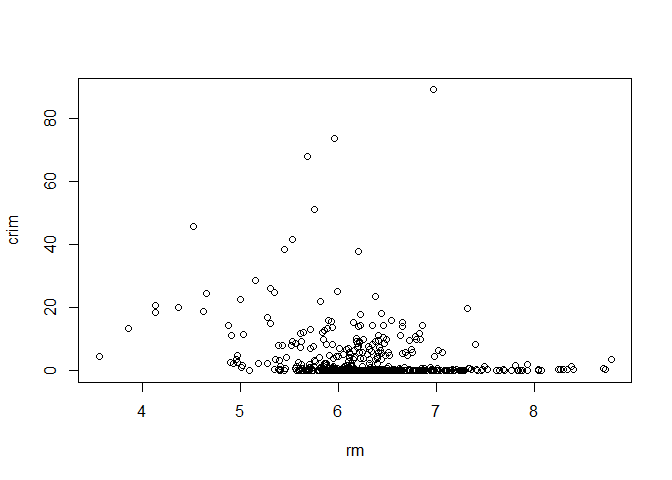

```r
plot(rm, crim, xlab="rm", ylab="crim")
```

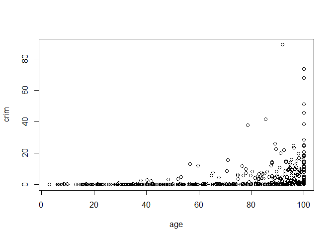

```r
plot(age, crim, xlab="age", ylab="crim")
```

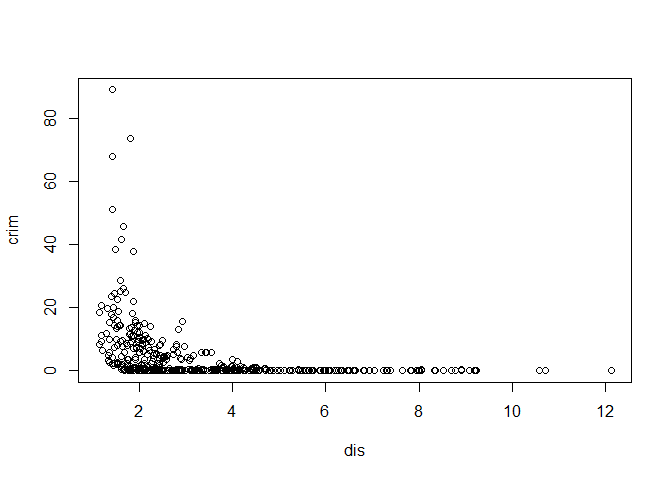

```r
plot(dis, crim, xlab="dis", ylab="crim")
```

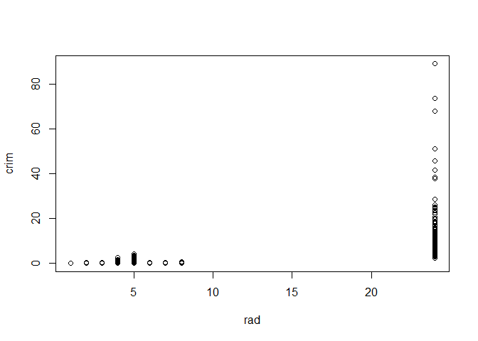

```r
plot(rad, crim, xlab="rad", ylab="crim")
```

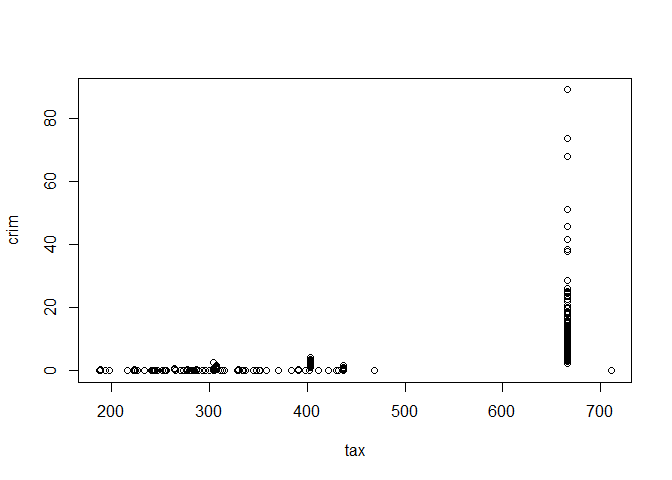

```r
plot(tax, crim, xlab="tax", ylab="crim")
```

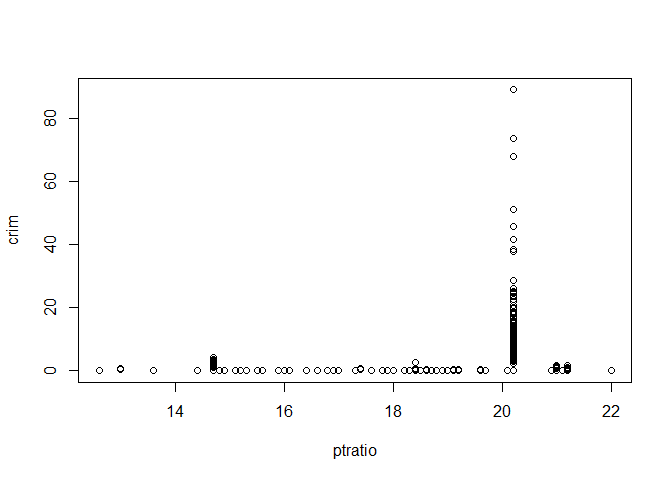

```r
plot(ptratio, crim, xlab="ptratio", ylab="crim")
```

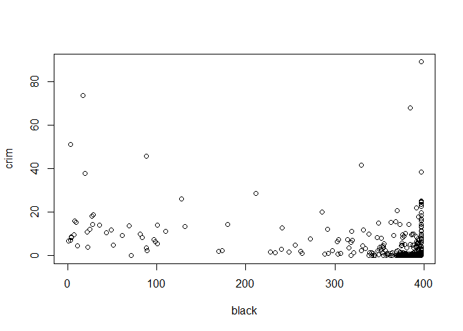

```r
plot(black, crim, xlab="black", ylab="crim")
```

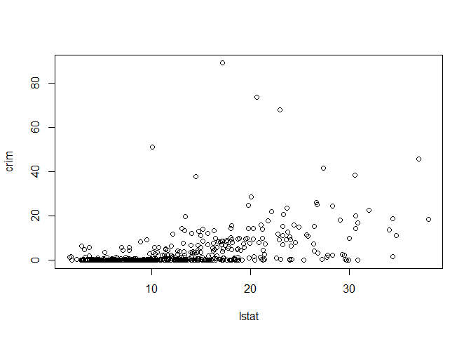

```r
plot(lstat, crim, xlab="lstat", ylab="crim")
```

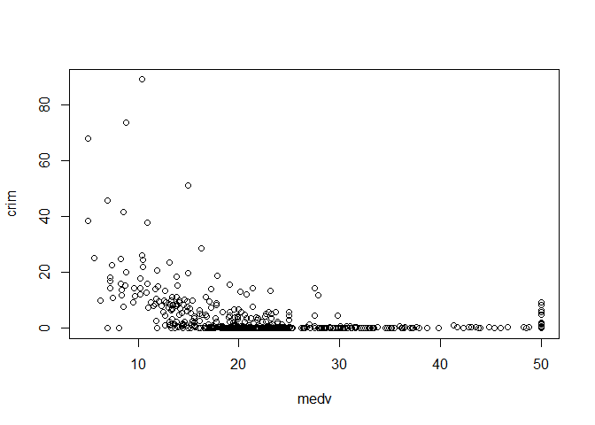

```r
plot(medv, crim, xlab="medv", ylab="crim")
```

# 10(d-h)

```r
#(d)
summary(Boston$crim)
```

```
##     Min.  1st Qu.   Median     Mean  3rd Qu.     Max.
##  0.00632  0.08204  0.25651  3.61352  3.67708 88.97620
```

```r
range(Boston$crim)
```

```
## [1]  0.00632 88.97620
```

```r
summary(Boston$tax)
```

```
##    Min. 1st Qu.  Median    Mean 3rd Qu.    Max.
##   187.0   279.0   330.0   408.2   666.0   711.0
```

```r
range(Boston$tax)
```

```
## [1] 187 711
```

```r
summary(Boston$ptratio)
```

```
##    Min. 1st Qu.  Median    Mean 3rd Qu.    Max.
##   12.60   17.40   19.05   18.46   20.20   22.00
```

```r
range(Boston$ptratio)
```

```
## [1] 12.6 22.0
```

```r
#(e)
as.data.frame(table(Boston$chas))
```

```
##   Var1 Freq
## 1    0  471
## 2    1   35
```

```r
#(f)
summary(Boston$ptratio)
```

```
##    Min. 1st Qu.  Median    Mean 3rd Qu.    Max.
##   12.60   17.40   19.05   18.46   20.20   22.00
```

```r
#(g)
summary(Boston$medv)
```

```
##    Min. 1st Qu.  Median    Mean 3rd Qu.    Max.
##    5.00   17.02   21.20   22.53   25.00   50.00
```

```r
range(Boston$medv)
```

```
## [1]  5 50
```

```r
#as.data.frame(table(Boston$medv))
min(Boston$medv)
```

```
## [1] 5
```

```r
attach(Boston)
newBoston <- Boston[order(medv),]
head(newBoston)
```

```
##         crim zn indus chas   nox    rm   age    dis rad tax ptratio  black
## 399 38.35180  0 18.10    0 0.693 5.453 100.0 1.4896  24 666    20.2 396.90
## 406 67.92080  0 18.10    0 0.693 5.683 100.0 1.4254  24 666    20.2 384.97
## 401 25.04610  0 18.10    0 0.693 5.987 100.0 1.5888  24 666    20.2 396.90
## 400  9.91655  0 18.10    0 0.693 5.852  77.8 1.5004  24 666    20.2 338.16
## 415 45.74610  0 18.10    0 0.693 4.519 100.0 1.6582  24 666    20.2  88.27
## 490  0.18337  0 27.74    0 0.609 5.414  98.3 1.7554   4 711    20.1 344.05
##     lstat medv
## 399 30.59  5.0
## 406 22.98  5.0
## 401 26.77  5.6
## 400 29.97  6.3
## 415 36.98  7.0
## 490 23.97  7.0
```

```r
#(h)
as.data.frame(table(Boston$rm))
```

```
##      Var1 Freq
## 1   3.561    1
## 2   3.863    1
## 3   4.138    2
## 4   4.368    1
## 5   4.519    1
## 6   4.628    1
## 7   4.652    1
## 8    4.88    1
## 9   4.903    1
## 10  4.906    1
## 11  4.926    1
## 12  4.963    1
## 13   4.97    1
## 14  4.973    1
```

[output cut: 432 more lines]

```r
library(plyr)
#count(which(Boston$rm > 7))
Bostonrm7 <- subset(Boston, rm > 7)
Bostonrm7
```

```
##         crim   zn indus chas    nox    rm   age    dis rad tax ptratio
## 3    0.02729  0.0  7.07    0 0.4690 7.185  61.1 4.9671   2 242    17.8
## 5    0.06905  0.0  2.18    0 0.4580 7.147  54.2 6.0622   3 222    18.7
## 41   0.03359 75.0  2.95    0 0.4280 7.024  15.8 5.4011   3 252    18.3
## 56   0.01311 90.0  1.22    0 0.4030 7.249  21.9 8.6966   5 226    17.9
## 65   0.01951 17.5  1.38    0 0.4161 7.104  59.5 9.2229   3 216    18.6
## 89   0.05660  0.0  3.41    0 0.4890 7.007  86.3 3.4217   2 270    17.8
## 90   0.05302  0.0  3.41    0 0.4890 7.079  63.1 3.4145   2 270    17.8
## 98   0.12083  0.0  2.89    0 0.4450 8.069  76.0 3.4952   2 276    18.0
## 99   0.08187  0.0  2.89    0 0.4450 7.820  36.9 3.4952   2 276    18.0
## 100  0.06860  0.0  2.89    0 0.4450 7.416  62.5 3.4952   2 276    18.0
## 162  1.46336  0.0 19.58    0 0.6050 7.489  90.8 1.9709   5 403    14.7
## 163  1.83377  0.0 19.58    1 0.6050 7.802  98.2 2.0407   5 403    14.7
## 164  1.51902  0.0 19.58    1 0.6050 8.375  93.9 2.1620   5 403    14.7
## 167  2.01019  0.0 19.58    0 0.6050 7.929  96.2 2.0459   5 403    14.7
```

[output cut: 115 more lines]

```r
Bostonrm8 <- subset(Boston, rm > 8)
Bostonrm8
```

```
##        crim zn indus chas    nox    rm  age    dis rad tax ptratio  black
## 98  0.12083  0  2.89    0 0.4450 8.069 76.0 3.4952   2 276    18.0 396.90
## 164 1.51902  0 19.58    1 0.6050 8.375 93.9 2.1620   5 403    14.7 388.45
## 205 0.02009 95  2.68    0 0.4161 8.034 31.9 5.1180   4 224    14.7 390.55
## 225 0.31533  0  6.20    0 0.5040 8.266 78.3 2.8944   8 307    17.4 385.05
## 226 0.52693  0  6.20    0 0.5040 8.725 83.0 2.8944   8 307    17.4 382.00
## 227 0.38214  0  6.20    0 0.5040 8.040 86.5 3.2157   8 307    17.4 387.38
## 233 0.57529  0  6.20    0 0.5070 8.337 73.3 3.8384   8 307    17.4 385.91
## 234 0.33147  0  6.20    0 0.5070 8.247 70.4 3.6519   8 307    17.4 378.95
## 254 0.36894 22  5.86    0 0.4310 8.259  8.4 8.9067   7 330    19.1 396.90
## 258 0.61154 20  3.97    0 0.6470 8.704 86.9 1.8010   5 264    13.0 389.70
## 263 0.52014 20  3.97    0 0.6470 8.398 91.5 2.2885   5 264    13.0 386.86
## 268 0.57834 20  3.97    0 0.5750 8.297 67.0 2.4216   5 264    13.0 384.54
## 365 3.47428  0 18.10    1 0.7180 8.780 82.9 1.9047  24 666    20.2 354.55
##     lstat medv
## 98   4.21 38.7
## 164  3.32 50.0
## 205  2.88 50.0
## 225  4.14 44.8
## 226  4.63 50.0
## 227  3.13 37.6
## 233  2.47 41.7
## 234  3.95 48.3
## 254  3.54 42.8
## 258  5.12 50.0
## 263  5.91 48.8
## 268  7.44 50.0
## 365  5.29 21.9
```